# all_data

## WICSPTH16

| Feature | Result |
| --- | --- |
| Variable type | numeric |
| Number of missing obs. | 240 (7.45 %) |
| Number of unique values | 2937 |
| Median | 0.17 |
| 1st and 3rd quartiles | 0.11; 0.25 |
| Min. and max. | 0; 3.26 |

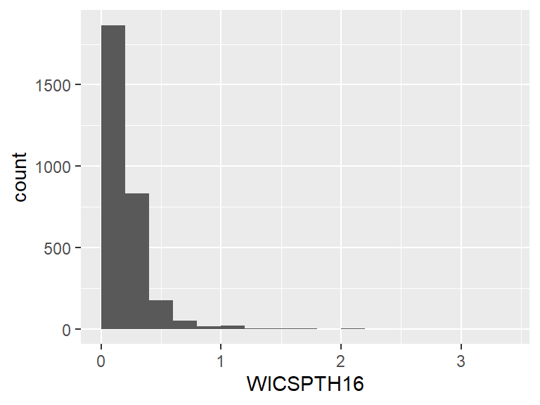

- Note that the following possible outlier values were detected: "0", "0.01", "0.01", "0.03", "0.04", …, "2.03", "2.06", "2.08", "2.21", "3.26" (104 values omitted).

## FFRPTH16

| Feature | Result |
| --- | --- |
| Variable type | numeric |
| Number of missing obs. | 82 (2.55 %) |
| Number of unique values | 2960 |
| Median | 0.59 |
| 1st and 3rd quartiles | 0.42; 0.75 |
| Min. and max. | 0; 5.81 |

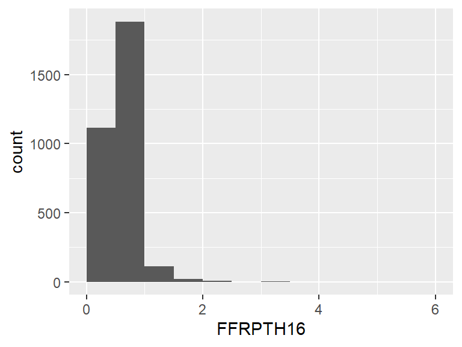

- Note that the following possible outlier values were detected: "1.15", "1.15", "1.16", "1.16", "1.16", …, "2.25", "3.4", "3.47", "3.51", "5.81" (61 values omitted).

## FSRPTH16

| Feature | Result |
| --- | --- |
| Variable type | numeric |
| Number of missing obs. | 82 (2.55 %) |
| Number of unique values | 3049 |
| Median | 0.67 |
| 1st and 3rd quartiles | 0.5; 0.89 |
| Min. and max. | 0; 11.61 |

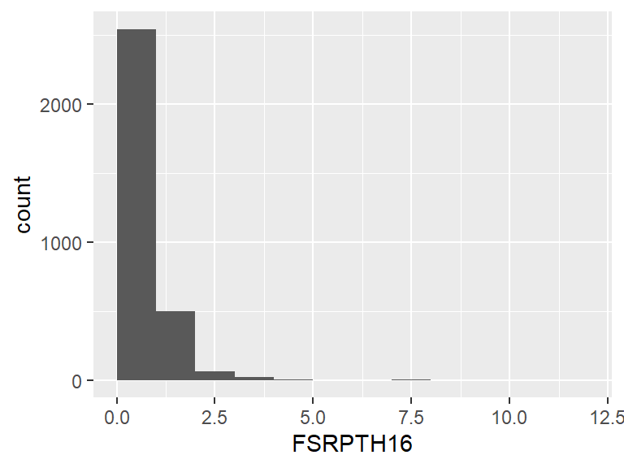

- Note that the following possible outlier values were detected: "0", "0.05", "0.05", "0.06", "0.07", …, "4.6", "5.25", "7.62", "7.95", "11.61" (174 values omitted).

## geometry

- The variable is a key (distinct values for each observation).
- The variable has class sfc_MULTIPOLYGON which is not supported by dataMaid.

## metro_class

- Note that this variable is treated as a factor variable below, as it only takes a few unique values.

| Feature | Result |
| --- | --- |
| Variable type | numeric |
| Number of missing obs. | 4 (0.12 %) |
| Number of unique values | 3 |
| Mode | “1” |
| Reference category | 1 |

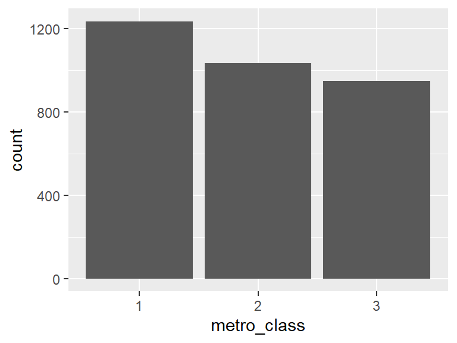

## metro_Desc

| Feature | Result |
| --- | --- |
| Variable type | character |
| Number of missing obs. | 4 (0.12 %) |
| Number of unique values | 3 |
| Mode | “metro” |

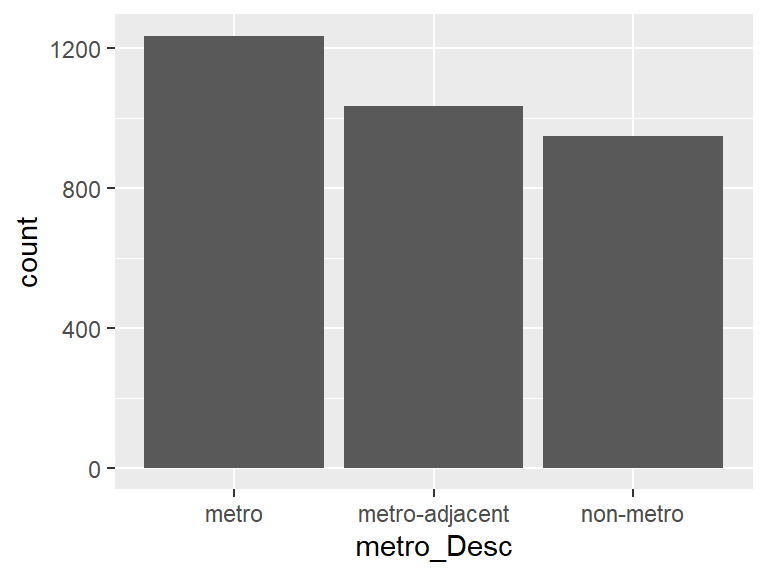

## metro_fact

| Feature | Result |
| --- | --- |
| Variable type | factor |
| Number of missing obs. | 4 (0.12 %) |
| Number of unique values | 3 |
| Mode | “1” |
| Reference category | 1 |

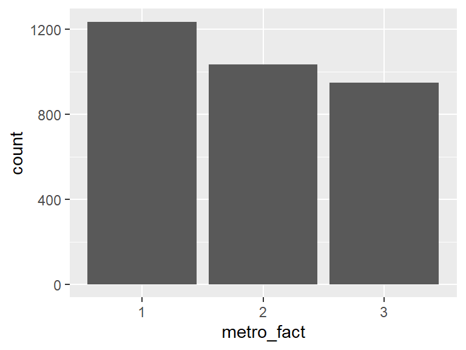

Report generation information:

- Created by: Omar Faison (username: `midlo`).
- Report creation time: Thu Jun 20 2024 13:10:36
- Report was run from directory: `D:/code/git/VSU_DSPG_SUM24/health_outcomes`
- dataMaid v1.4.1 [Pkg: 2021-10-08 from CRAN (R 4.3.3)]
- R version 4.3.0 (2023-04-21 ucrt).
- Platform: x86_64-w64-mingw32/x64 (64-bit)(America/New_York).
- Function call: `makeDataReport(data = all_data, output = "html", replace = T)`